# SL/ML Playground

by Roger Sourm

# Regression

Regression is a statistical method that estimates the relationship between the response variable and the explanatory variable(s). Some commonly used regression methods include linear regression, polynomial regression, and logistic regression.

## Linear Regression

### Simple Linear Regression

Simple linear regression fits a straight line to points on a scatter plot involving two variables. The regression line displays the linear trend and can be used to make predictions.

A simple linear regression model expressing the relationship between $y_i$ and $x_i$ is given by:

$$Y = \beta_0 + \beta_1X + \epsilon$$

- $\{(x_i, y_i): i=1,2,...,n\}$
- $Y$: response variable
- $X$: explanatory variable
- $\beta_0$: intercept parameter
- $\beta_1$: slope parameter
- $\epsilon$: the random error term; assume it takes on a normal distribution.

The fitted linear regression model is expressed by:

$$\hat y = \hat\beta_0 + \hat\beta_1x.$$

We will use the Ames Housing data set from the `AmesHousing` package. This data set contains 2930 records of homes in Ames, Iowa. There are are 81 variables, which are:

```r
library(AmesHousing)

# Creates a processed version of the Ames Housing data.
ames <- make_ames()

# Variable names.
names(ames)
```

```
##  [1] "MS_SubClass"        "MS_Zoning"          "Lot_Frontage"
##  [4] "Lot_Area"           "Street"             "Alley"
##  [7] "Lot_Shape"          "Land_Contour"       "Utilities"
## [10] "Lot_Config"         "Land_Slope"         "Neighborhood"
## [13] "Condition_1"        "Condition_2"        "Bldg_Type"
## [16] "House_Style"        "Overall_Qual"       "Overall_Cond"
## [19] "Year_Built"         "Year_Remod_Add"     "Roof_Style"
## [22] "Roof_Matl"          "Exterior_1st"       "Exterior_2nd"
## [25] "Mas_Vnr_Type"       "Mas_Vnr_Area"       "Exter_Qual"
## [28] "Exter_Cond"         "Foundation"         "Bsmt_Qual"
## [31] "Bsmt_Cond"          "Bsmt_Exposure"      "BsmtFin_Type_1"
## [34] "BsmtFin_SF_1"       "BsmtFin_Type_2"     "BsmtFin_SF_2"
## [37] "Bsmt_Unf_SF"        "Total_Bsmt_SF"      "Heating"
## [40] "Heating_QC"         "Central_Air"        "Electrical"
## [43] "First_Flr_SF"       "Second_Flr_SF"      "Low_Qual_Fin_SF"
## [46] "Gr_Liv_Area"        "Bsmt_Full_Bath"     "Bsmt_Half_Bath"
## [49] "Full_Bath"          "Half_Bath"          "Bedroom_AbvGr"
## [52] "Kitchen_AbvGr"      "Kitchen_Qual"       "TotRms_AbvGrd"
## [55] "Functional"         "Fireplaces"         "Fireplace_Qu"
## [58] "Garage_Type"        "Garage_Finish"      "Garage_Cars"
## [61] "Garage_Area"        "Garage_Qual"        "Garage_Cond"
## [64] "Paved_Drive"        "Wood_Deck_SF"       "Open_Porch_SF"
## [67] "Enclosed_Porch"     "Three_season_porch" "Screen_Porch"
## [70] "Pool_Area"          "Pool_QC"            "Fence"
## [73] "Misc_Feature"       "Misc_Val"           "Mo_Sold"
## [76] "Year_Sold"          "Sale_Type"          "Sale_Condition"
## [79] "Sale_Price"         "Longitude"          "Latitude"
```

The sale price (`Sale_Price`) is the variable of interest, thus is the response variable. Let’s arbitrarily use the area of the ground square footage (`Gr_Liv_Area`) as the explanatory variable. The `lm()` function will be used to fit a simple linear regression model.

Note: To indicate that a response variable, y, is dependent on the explanatory, x, we use the follow formula, `y ~ x`. We will see this in the following example.

```r
lm1 <- lm(Sale_Price ~ Gr_Liv_Area, data = ames)
lm1
```

```
##
## Call:
## lm(formula = Sale_Price ~ Gr_Liv_Area, data = ames)
##
## Coefficients:
## (Intercept)  Gr_Liv_Area
##    13289.63       111.69
```

The output of calling `lm1` displays the formula and the estimated coefficients, $\hat\beta_0$ and $\hat\beta_1$. A better way to look at the model would be to use the `summary()` function. Using the `summary()` function will give more information such as the $R^2$ which can be used for model assessment.

```r
summary(lm1)
```

```
##
## Call:
## lm(formula = Sale_Price ~ Gr_Liv_Area, data = ames)
##
## Residuals:
##     Min      1Q  Median      3Q     Max
## -483467  -30219   -1966   22728  334323
##
## Coefficients:
##               Estimate Std. Error t value  Pr(>|t|)
## (Intercept) 13289.6344  3269.7028  4.0645 4.941e-05 ***
## Gr_Liv_Area   111.6940     2.0661 54.0610 < 2.2e-16 ***
## ---
## Signif. codes:  0 '***' 0.001 '**' 0.01 '*' 0.05 '.' 0.1 ' ' 1
##
## Residual standard error: 56524 on 2928 degrees of freedom
## Multiple R-squared:  0.49954,    Adjusted R-squared:  0.49937
## F-statistic: 2922.6 on 1 and 2928 DF,  p-value: < 2.22e-16
```

Substituting the estimated coefficients of the output in the fitted linear regression model, we get:

$$\widehat{\text{Sale Price}} = 13289.6 + 111.7(x).$$

The formula for a specific $i^{th}$ observation would be:

$$\widehat{\text{Sale Price}_i} = 13289.6 + 111.7(\text{Gr_Liv_Area}_i).$$

The scatter plot and the regression line of the fitted model is shown below.

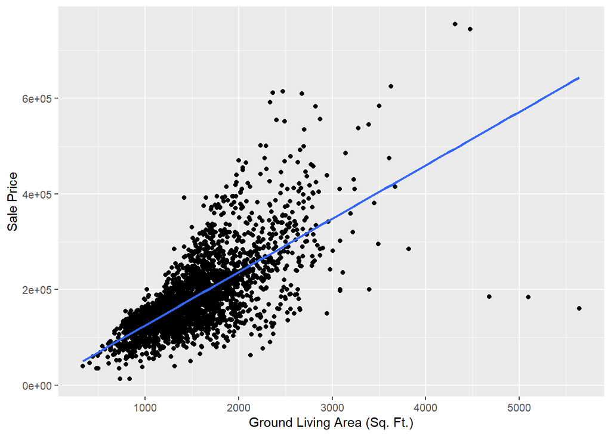

```r
ggplot(data = ames, aes(Gr_Liv_Area, Sale_Price)) +
  geom_point() +
  geom_smooth(formula = y ~ x, se = FALSE) +
  labs(x = "Ground Living Area (Sq. Ft.)",
       y = "Sale Price")
```

### Multiple Linear Regression

Multiple linear regression is essentially the same as simple linear regression except that multiple predictor variables are used as opposed to just one. Multiple linear regression is expressed by:

$$Y = \beta_0 + \beta_1X_1 + \beta_2X_2 + ... + \beta_pX_p + \epsilon$$

- $\{(x_{ij}, y_i): i=1,2,...,n; j = 1,2, ...,p \}$
- $Y$: response variable
- $X_j$: $j^{th}$ explanatory variable
- $\beta_0$: intercept parameter
- $\beta_j$: $j^{th}$ slope parameter.

We interpret the $j^{th}$ slope parameter, $\beta_j$, as the average effect on $Y$ of a one unit increase in $X_j$, holding all other predictors fixed.

The fitted multiple linear regression model is expressed by:

$$\hat y = \hat\beta_0 + \hat\beta_1x_1 + \hat\beta_2x_2 + ... +
\hat\beta_px_p.$$

To fit a multiple linear regression model, the `lm()` can still be used. Just use the addition operator, `+`, to add additional predictors.

For the following example, we will regress the sale price on both the ground square footage and the total amount of rooms above ground (`TotRms_AbvGrd`).

```r
mlm1 <- lm(Sale_Price ~ Gr_Liv_Area + TotRms_AbvGrd, data = ames)
summary(mlm1)
```

```
##
## Call:
## lm(formula = Sale_Price ~ Gr_Liv_Area + TotRms_AbvGrd, data = ames)
##
## Residuals:
##     Min      1Q  Median      3Q     Max
## -536994  -29779   -1700   21748  360615
##
## Coefficients:
##                  Estimate  Std. Error t value  Pr(>|t|)
## (Intercept)    42767.6361   4372.5328  9.7810 < 2.2e-16 ***
## Gr_Liv_Area      139.4075      3.4476 40.4363 < 2.2e-16 ***
## TotRms_AbvGrd -11025.8696   1107.9608 -9.9515 < 2.2e-16 ***
## ---
## Signif. codes:  0 '***' 0.001 '**' 0.01 '*' 0.05 '.' 0.1 ' ' 1
##
## Residual standard error: 55601 on 2927 degrees of freedom
## Multiple R-squared:  0.51592,    Adjusted R-squared:  0.51559
## F-statistic: 1559.7 on 2 and 2927 DF,  p-value: < 2.22e-16
```

The fitted multiple linear regression model would be:

$$\widehat{\text{Sale Price}} = 42,767.6361 +
139.4075(\text{Gr_Liv_Area}) + -11025.8696(\text{TotRms_AbvGrd}).$$

Let’s make a prediction using the fitted multiple linear model. We will predict the sale price of a house that has 1500 square footage and a total room of 7.

```r
predict(mlm1, newdata = data.frame(Gr_Liv_Area = 1500,
                                   TotRms_AbvGrd = 7))
```

```
##         1
## 174697.84
```

This prediction can be calculated by inputting the values in the formula above.

$$\widehat{\text{Sale Price}} = 42,767.6361 + 139.4075(1500) +
-11,025.8696(7)=$174,697.84.$$

## Polynomial Regression

Polynomial regression is similar to linear regression in the sense that it still tries to fit a line to the data points, but what makes it different from linear regression is that the line is curvilinear rather than simply just linear. The explanatory variable(s) are modeled in the $n^{th}$ degree polynomial which the value for $n$ is arbitrarily dependent on which seem to fit the data points best. We use the `poly()` function to do this.

Note: Performing model assessment can also help to determine an appropriate value for $n$.

First, let’s look at a linear regression fit. Using the same data set, we will construct a linear model using the year built (`Year_Built`) as the explanatory variable and sale price (`Sale_Price`), in thousands, as the response variable.

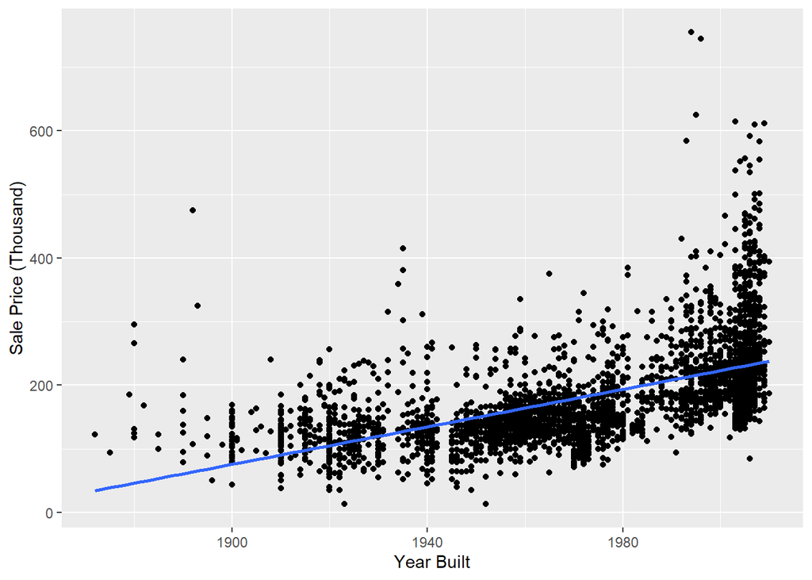

```r
ggplot(data = ames, aes(Year_Built, Sale_Price/1000)) +
  geom_point() +
  geom_smooth(formula = y ~ x, se = FALSE) +
  labs(x = "Year Built",
      y = "Sale Price (Thousand)")
```

We can see that the linear regression line seems to fit the data okay. Maybe not so well with the houses built from 1872 to 1990. By adding some curvature to the line, we may get a better fit. To fit a polynomial regression, we still use the `lm()` function while passing the explanatory variable into the `poly()` function.

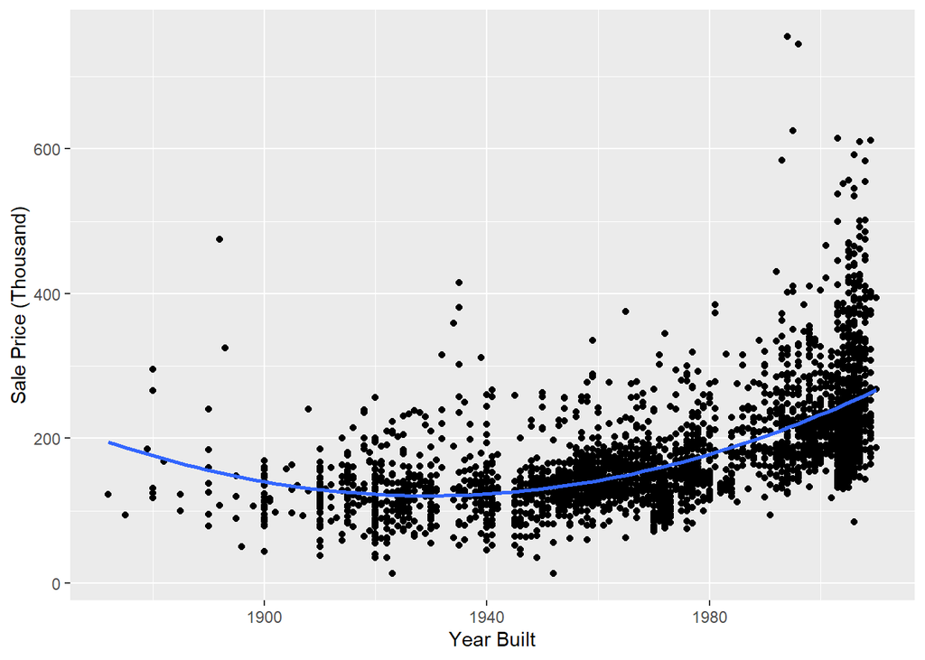

```r
ggplot(data = ames, aes(Year_Built, Sale_Price/1000)) +
  geom_point() +
  geom_smooth(formula = y ~ poly(x, 2), se = FALSE) +
  labs(x = "Year Built",
      y = "Sale Price (Thousand)")
```

Fitting a polynomial regression line in the $2^{nd}$ degree looks like it fits the data much better than the linear model. Let’s take a look at the $3^{rd}$, $5^{th}$, and $8^{th}$ degree polynomial model.

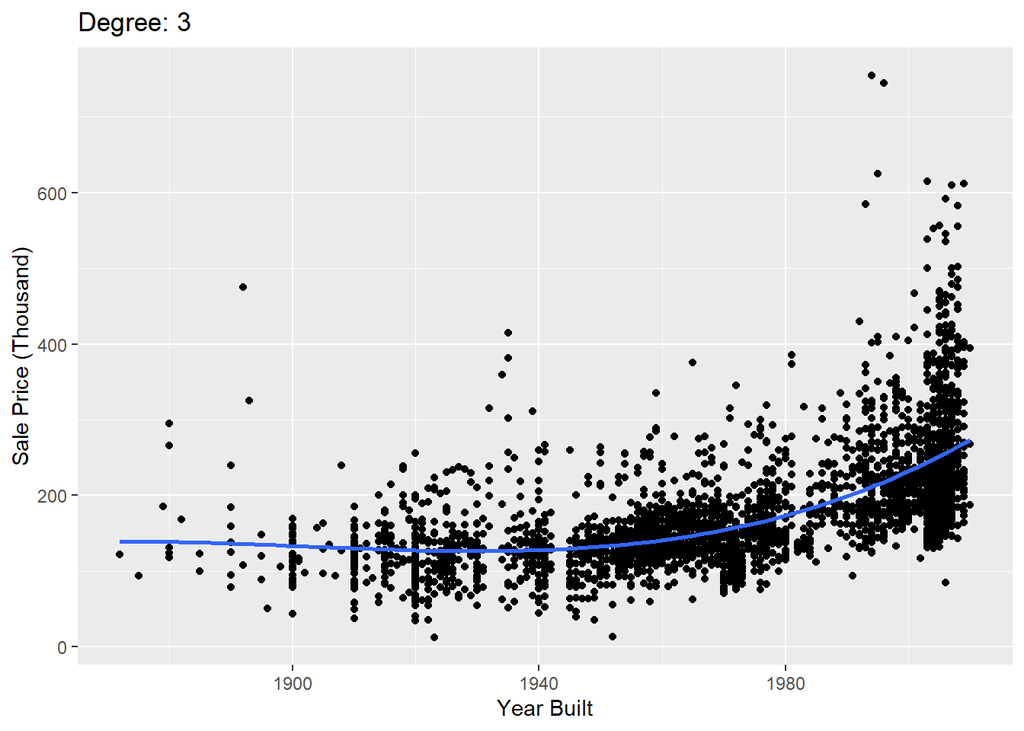

```r
ggplot(data = ames, aes(Year_Built, Sale_Price/1000)) +
  geom_point() +
  geom_smooth(formula = y ~ poly(x, 3), se = FALSE) +
  labs(x = "Year Built",
      y = "Sale Price (Thousand)",
      title = "Degree: 3")
```

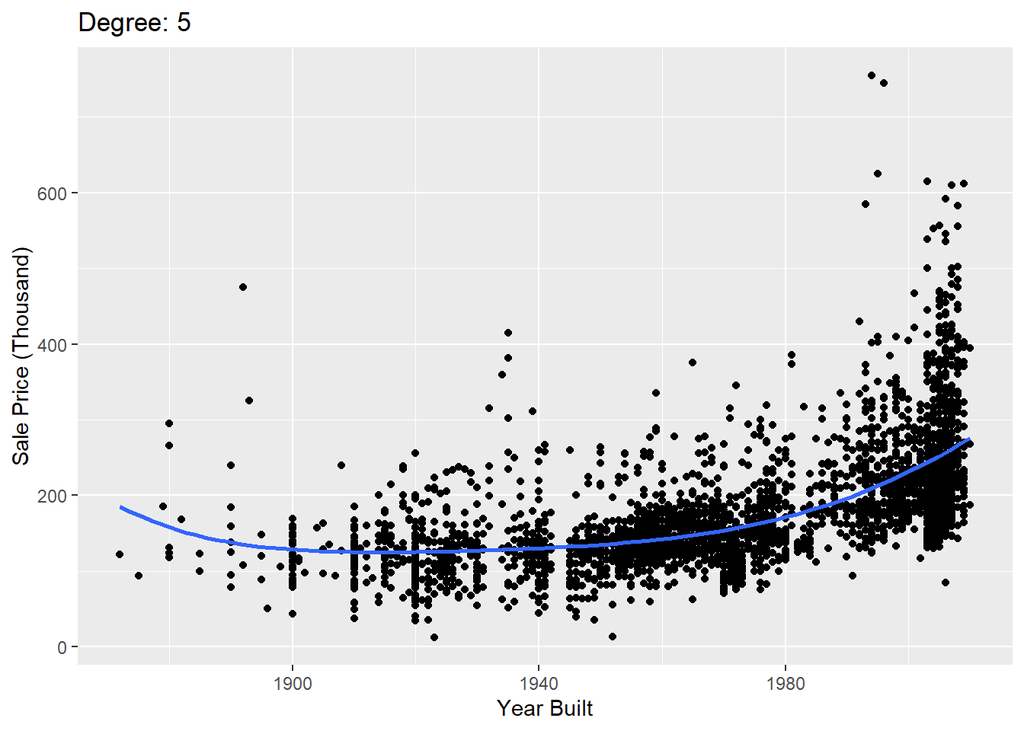

```r
ggplot(data = ames, aes(Year_Built, Sale_Price/1000)) +
  geom_point() +
  geom_smooth(formula = y ~ poly(x, 5), se = FALSE) +
  labs(x = "Year Built",
      y = "Sale Price (Thousand)",
      title = "Degree: 5")
```

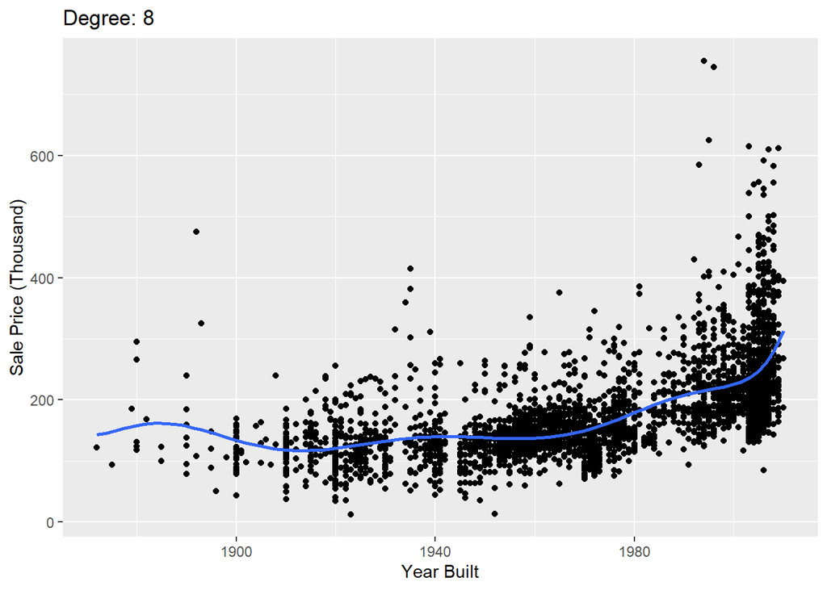

```r
ggplot(data = ames, aes(Year_Built, Sale_Price/1000)) +
  geom_point() +
  geom_smooth(formula = y ~ poly(x, 8), se = FALSE) +
  labs(x = "Year Built",
      y = "Sale Price (Thousand)",
      title = "Degree: 8")
```

```r
# Creating the polynomial regression model with degree 2, 3, 5, and 8.
plm2 <- lm(data = ames, (Sale_Price/1000) ~ poly(Year_Built, 2))
plm3 <- lm(data = ames, (Sale_Price/1000) ~ poly(Year_Built, 3))
plm5 <- lm(data = ames, (Sale_Price/1000) ~ poly(Year_Built, 5))
plm8 <- lm(data = ames, (Sale_Price/1000) ~ poly(Year_Built, 8))

# Model assessment.
cat("Linear R-Squared:", summary(lm(data = ames, (Sale_Price/1000) ~ Year_Built))$r.sq)
```

```
## Linear R-Squared: 0.31183972
```

```r
cat("Degree 2 R-Squared:", summary(plm2)$r.sq)
```

```
## Degree 2 R-Squared: 0.38708783
```

```r
cat("Degree 3 R-Squared:", summary(plm3)$r.sq)
```

```
## Degree 3 R-Squared: 0.38995552
```

```r
cat("Degree 5 R-Squared:", summary(plm5)$r.sq)
```

```
## Degree 5 R-Squared: 0.39082779
```

```r
cat("Degree 8 R-Squared:", summary(plm8)$r.sq)
```

```
## Degree 8 R-Squared: 0.39761424
```

We can see there was a significant improvement in the $R^2$ from the linear model to the $2^{nd}$ degree polynomial model. Since going from degree 2 to degree 3, 5, or 8 didn’t greatly improve the $R^2$, using the $2^{nd}$ degree polynomial model should suffice.

## Logistic Regression

Logistic regression is a method that is used to determine the probability of a binary qualitative response. When we apply an arbitrary threshold, commonly 0.5, to the predicted numerical output of a logistic regression, we can classify the output as either one of the 2 binary qualitative choices. This makes logistic regression suitable to be used for a binary classification.

To fit a logistic regression, we use the `glm()` function. `glm()` is the generalized linear model function. This function can also be used to fit many other regression model by supplying the `family` parameter with one of these arguments, `binomial`, `gaussian`, `Gamma`, `inverse.gaussian`, `poisson`, `quasi`, `quasibinomial`, and `quasipoisson`. Be default, the `glm()` function fits a linear regression model, making it the same as the `lm()` function.

The following example will use the `NHANES` data set from the `NHANES` package.

```
## Rows: 10,000
## Columns: 76
## $ ID               <int> 51624, 51624, 51624, 51625, 51630, 51638, 51646, 5164…
## $ SurveyYr         <fct> 2009_10, 2009_10, 2009_10, 2009_10, 2009_10, 2009_10,…
## $ Gender           <fct> male, male, male, male, female, male, male, female, f…
## $ Age              <int> 34, 34, 34, 4, 49, 9, 8, 45, 45, 45, 66, 58, 54, 10, …
## $ AgeDecade        <fct>  30-39,  30-39,  30-39,  0-9,  40-49,  0-9,  0-9,  40…
## $ AgeMonths        <int> 409, 409, 409, 49, 596, 115, 101, 541, 541, 541, 795,…
## $ Race1            <fct> White, White, White, Other, White, White, White, Whit…
## $ Race3            <fct> NA, NA, NA, NA, NA, NA, NA, NA, NA, NA, NA, NA, NA, N…
## $ Education        <fct> High School, High School, High School, NA, Some Colle…
## $ MaritalStatus    <fct> Married, Married, Married, NA, LivePartner, NA, NA, M…
## $ HHIncome         <fct> 25000-34999, 25000-34999, 25000-34999, 20000-24999, 3…
## $ HHIncomeMid      <int> 30000, 30000, 30000, 22500, 40000, 87500, 60000, 8750…
## $ Poverty          <dbl> 1.36, 1.36, 1.36, 1.07, 1.91, 1.84, 2.33, 5.00, 5.00,…
```

[output cut: 63 more lines]

```
## [1] 10000    76
```

We will construct a logistic regression using whether a person has diabetes or not (`Diabetes`) as the response variable and the body mass index (`BMI`) as the explanatory variable. We will select the variables of interest and check to see if they contain any missing values. If they do, we will first drop the rows with the missing values.

```r
# Variable selection.
nhanes_data <- NHANES %>%
  select(Diabetes, BMI)

# Checking for missing values.
anyNA(nhanes_data)
```

```
## [1] TRUE
```

```r
# Drop any row with missing values.
library(tidyr)
diabetes_data <- nhanes_data %>% drop_na()

# Encode the response variable.
diabetes_data <- diabetes_data %>%
  mutate(Diabetes = ifelse(Diabetes == "Yes", 1, 0))

# Fitting the logistic regression.
logreg1 <- glm(Diabetes ~ BMI, family = "binomial",
              data = diabetes_data)
```

Let’s plot the logistic regression with a threshold of 0.5.

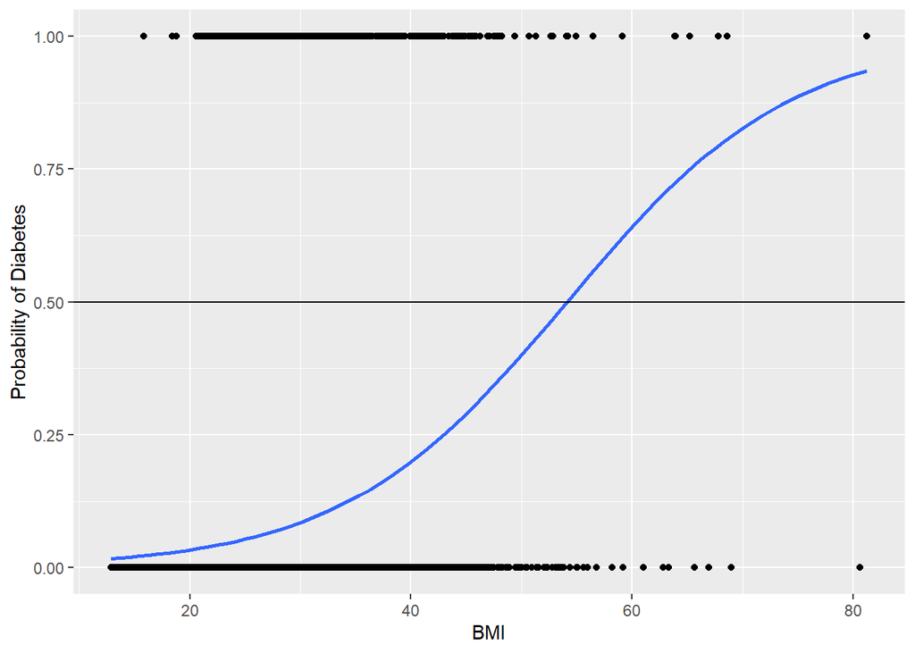

```r
ggplot(diabetes_data, aes(BMI, Diabetes)) +
  geom_point() +
  geom_smooth(method = "glm",
              method.args = list(family = "binomial"),
              se = FALSE) +
  labs(y = "Probability of Diabetes") +
  geom_hline(yintercept = 0.5)
```

For this example, let’s say that anything above 0.5 would be classified has having diabetes. Anything data point that is 0.5 or lower would not have diabetes. We will continue the classification procedure for this example in the *Classification* section.

# Classification

## Logistic Regression

Extending from the example of the logistic regression from the *Regression* section, we will classify the results of the prediction using the same data set. We will also create a confusion matrix to assess the model. Performing cross-validation and then creating a confusion matrix will give us a better assessment of a model’s predictive performance, but we won’t do that here. Cross-validation will be discuss in greater details in another reference document. For now, we just want to showcase how to classify the probabilities of the model’s output.

When making a prediction for classification, make sure to supply the `type` argument with “response”. The `ifelse()` function will be used to classify any probabilities that greater than 0.5 as 1 (Yes) and anything 0.5 or lower as 0 (No).

```r
# Prediction output.
logreg_pred <- predict(logreg1, newdata = diabetes_data, type = "response")

# Classifying the prediction probabilities.
logreg_pred <- ifelse(logreg_pred > 0.5, 1, 0)

cm <- table(Predicted = logreg_pred,
            Actual = diabetes_data$Diabetes)
addmargins(cm)
```

```
##          Actual
## Predicted    0    1  Sum
##       0   8855  734 9589
##       1     25   15   40
##       Sum 8880  749 9629
```

We can see that the model predicted 8855 No’s and 15 Yes’s correctly, but misclassified 25 No’s as Yes and 734 Yes’s as No.

The accuracy of the logistic model would be $(8855+15)/9629=0.9211756$. Pretty good.

## K-Nearest Neighbors

K-nearest neighbors or KNN is a method that makes predictions for new data points based on other nearby data points that are already classified. The `K` represents an arbitrarily chosen value which is the number of closest neighbors to the new data points that the KNN looks at to determine what the new data points will become. Let’s look at the following image to get a better understanding of KNN. We will have it set to `k = 3`.

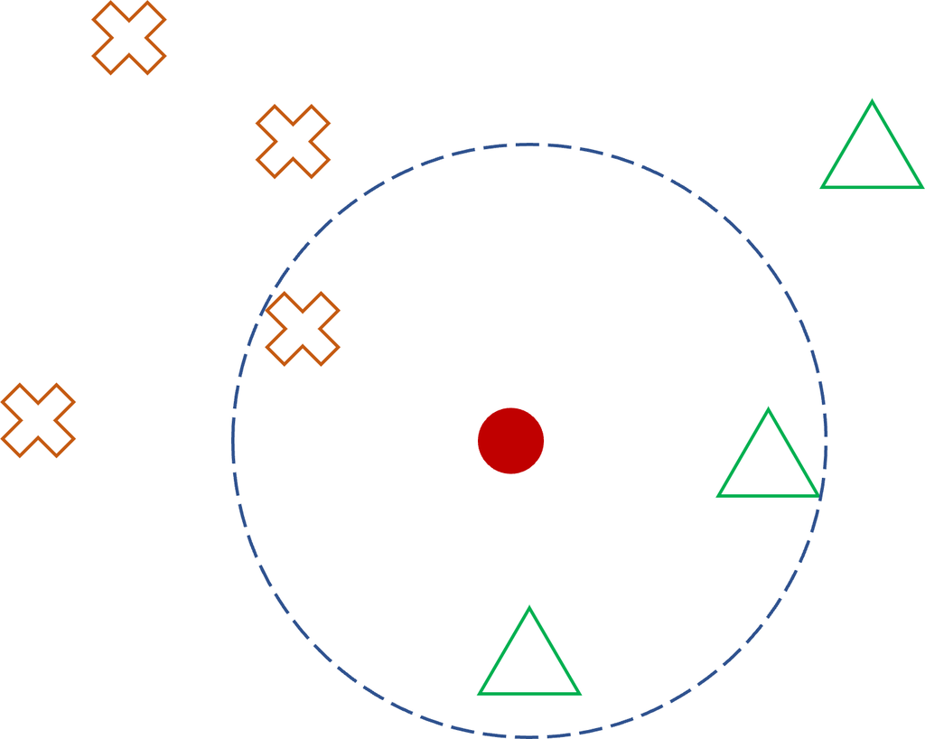

The red dot represents a new data point. The dashed lines represents the boundary that captures the 3 nearest neighbors within it. As we can see, the 3 nearest neighbors are 1 orange X and 2 green triangles. The new data point becomes the majority, which in this case, it becomes a green triangle. If we had set `k = 5`, the 5 nearest neighbors would have been 2 orange X’s and 3 green triangle, which still result with the new data point becoming a green triangle.

NOTE: `k` should be an odd number to avoid any ties.

To use the KNN method, we will use the `knn()` function from the `class` package. The `iris` data set will be used to run the KNN method. We will use KNN to help determine whether the classification of a flower will be Setosa, Versicolor, or Virginica based off of the flower’s petal length, petal width, sepal length, and sepal width. Before using the KNN function, we will scale the explanatory variables and create a training and test set.

```r
library(class)


# Scale the explanatory variables.
scaled_iris <- iris %>% mutate(
  Sepal.Length = scale(Sepal.Length),
  Sepal.Width = scale(Sepal.Width),
  Petal.Length = scale(Petal.Length),
  Petal.Width = scale(Sepal.Width),
)


# Cross-validation for model assessment.
n <- nrow(scaled_iris)

set.seed(777)
index <- sample(1:n, n*0.8)
X_train <- scaled_iris[index, -which(names(scaled_iris)=="Species")]
X_test <- scaled_iris[-index, -which(names(scaled_iris)=="Species")]
y_train <- scaled_iris$Species[index]
y_test <- scaled_iris$Species[-index]
```

Now we will perform the KNN method with `k = 3`, `k = 5`, and `k = 7`. Then we will assess the accuracy by constructing a confusion matrix.

```r
# knn with k = 3.
knn3_pred <- knn(X_train, X_test, y_train, k = 3)

## Confusion matrix.
cm3 <- addmargins(table(Predicted = knn3_pred,
                 Actual = y_test))
# Assessment.
accuracy3 <- sum(diag(cm3)[1:3]) / diag(cm3)[[4]]


# knn with k = 5.
knn5_pred <- knn(X_train, X_test, y_train, k = 5)

## Confusion matrix.
cm5 <- addmargins(table(Predicted = knn5_pred,
                 Actual = y_test))
# Assessment.
accuracy5 <-sum(diag(cm5)[1:3]) / diag(cm5)[[4]]


# knn with k = 7.
knn7_pred <- knn(X_train, X_test, y_train, k = 7)

## Confusion matrix.
cm7 <- addmargins(table(Predicted = knn7_pred,
                 Actual = y_test))
# Assessment.
accuracy7 <-sum(diag(cm7)[1:3]) / diag(cm7)[[4]]
```

```
##             Actual
## Predicted    setosa versicolor virginica Sum
##   setosa          4          0         0   4
##   versicolor      0          9         0   9
##   virginica       0          6        11  17
##   Sum             4         15        11  30
```

```
## k = 3: (4+9+11)/30 = 0.8
```

```
##             Actual
## Predicted    setosa versicolor virginica Sum
##   setosa          4          0         0   4
##   versicolor      0         12         1  13
##   virginica       0          3        10  13
##   Sum             4         15        11  30
```

```
## k = 5: (4+12+10)/30 = 0.86666667
```

```
##             Actual
## Predicted    setosa versicolor virginica Sum
##   setosa          4          0         0   4
##   versicolor      0         11         1  12
##   virginica       0          4        10  14
##   Sum             4         15        11  30
```

```
## k = 7: (4+11+10)/30 = 0.83333333
```

We select the KNN model with `k = 5` since it has the better accuracy.

## Decision Trees

A classification decision tree or just classification tree is a method used to predict a qualitative response by going down a hierarchy tree. The way it goes down the tree depends on certain conditions based off of the explanatory variable(s). To fit a classification tree, we will use `rpart()` function from the `rpart` package. Since we want to perform classification, set the `method` parameter as “class”.

```r
library(rpart)


# Fitting the classification tree.
tree1 <- rpart(Species~., data = iris,
               method = "class")

# Prediction.
tree_pred <- predict(tree1, iris, type = "class")


# Confusion matrix.
tree_cm <- table(Predicted = tree_pred,
                 Actual = iris$Species)
addmargins(tree_cm)
```

```
##             Actual
## Predicted    setosa versicolor virginica Sum
##   setosa         50          0         0  50
##   versicolor      0         49         5  54
##   virginica       0          1        45  46
##   Sum            50         50        50 150
```

```
## [1] Accuracy: (50+49+45) / 150 = 0.96
```

Let’s take a look at the plot for this classification tree. We will do this by using the `rpart.plot()` function from the `rpart.plot` package.

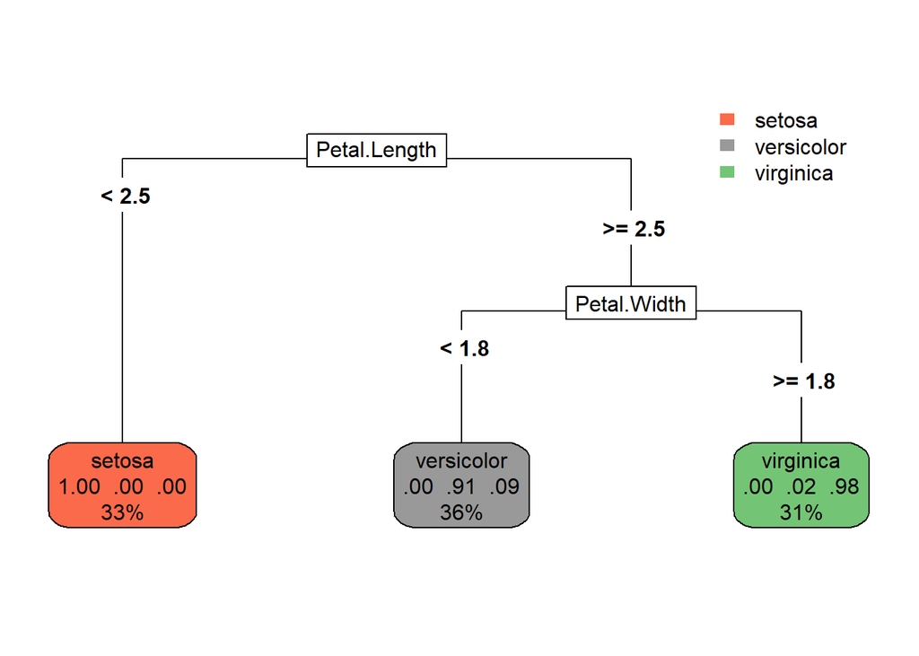

```r
library(rpart.plot)

# Plotting the fitted classification tree from above.
rpart.plot(tree1, type = 5)
```

To classify a new data point, we would first ask if the petal length is less than 2.5 cm, or greater than or equal to 2.5 cm. Depending on the length, we would move left or right down the decision tree. We would proceed down the tree until we reach a terminal node or leaf node. The classification of new data points depend on which leaf node was reached for each new data point.

NOTE: Decision trees also work for regression which is called a regression tree.

# Ending Notes

There are many other regression and classification methods. This reference will be updated when I learn more statistical and machine learning methods.